# Études qualitatives sur le web - Séance 2

SB

06/10/2020

```r
knitr::opts_chunk$set(echo = TRUE)
library(readxl)
library(tidyverse)
library(quanteda)
```

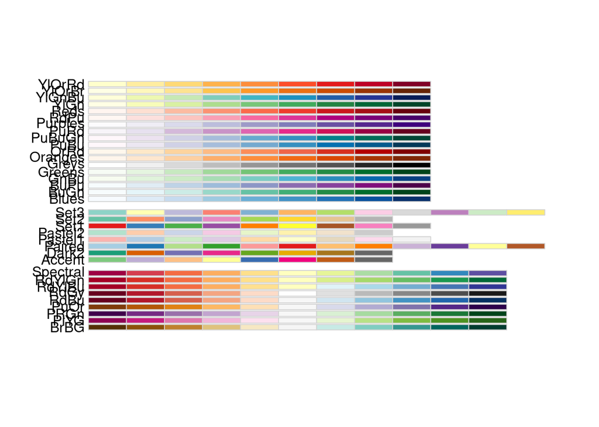

```r
library(quanteda.textstats)
library(quanteda.textplots)
library(RColorBrewer)
display.brewer.all()
```

# Pour commencer, un outil de scrapping

Voici un petit outil pour scrapper directement en R : [Rvest](https://github.com/tidyverse/rvest) (et ici un [tuto complet](https://thinkr.fr/rvest/)). Il vous permettra de constituer des jeux de données en direct, à condition de bien maîtriser html et de passer un peu de temps à explorer les tutos en ligne.

```r
library(rvest)
darty<-read_html("https://fr.trustpilot.com/review/www.darty.com")

d2<-darty%>%html_elements("section")

d2%>%html_element("h2")%>%html_text2()
```

```
##  [1] NA
##  [2] NA
##  [3] "4 727 • Mauvais"
##  [4] "4 727 • Mauvais"
##  [5] NA
##  [6] "Écrire un avis"
##  [7] "Dégoûtée !!!"
##  [8] "Assurance darty pour téléphone"
##  [9] "J’ai commandé une cuisine chez Darty…"
## [10] "Inacceptable"
## [11] "Incompétence"
## [12] "Click and Collect"
## [13] "SCANDALEUX !!!!"
## [14] "Ma colère et à la hauteur de…"
## [15] "Commande arrivée avec produits…"
```

[output cut: 26 more lines]

```r
d2%>%html_elements("a")%>%html_attr("href")
```

```
##   [1] NA
##   [2] NA
##   [3] NA
##   [4] "https://fr.trustpilot.com/categories/electronics_technology"
##   [5] "https://fr.trustpilot.com/categories/audio_visual"
##   [6] "https://fr.trustpilot.com/categories/photo_shop"
##   [7] "https://www.darty.com/achat/contacts/chat-service-client/index.html?utm_medium=company_profile&utm_source=trustpilot&utm_campaign=logo_click"
##   [8] "https://fr.trustpilot.com/categories/photo_shop"
##   [9] "https://www.darty.com/achat/contacts/chat-service-client/index.html?utm_medium=company_profile&utm_source=trustpilot&utm_campaign=domain_click"
##  [10] "https://www.darty.com/achat/contacts/chat-service-client/index.html?utm_medium=company_profile&utm_source=trustpilot&utm_campaign=domain_click"
##  [11] "/evaluate/www.darty.com"
##  [12] "https://www.darty.com/achat/contacts/chat-service-client/index.html?utm_medium=company_profile&utm_source=trustpilot&utm_campaign=domain_click"
##  [13] NA
##  [14] "/evaluate/www.darty.com"
##  [15] "/evaluate/www.darty.com"
```

[output cut: 85 more lines]

```r
rm(darty, d2)
```

# Reprenons avec Airbnb : Les données

```r
data<-read_excel("data_airbnb_sample.xlsx",
    col_types = c("numeric", "numeric", "numeric",
        "numeric", "numeric", "date", "numeric",
        "text", "text", "numeric", "text",
        "numeric"))
```

```
## * `` -> ...1
```

```r
summary(data$nbcar)
```

```
##    Min. 1st Qu.  Median    Mean 3rd Qu.    Max.    NA's
##     9.0    91.0   160.5   201.7   263.0  1559.0       6
```

```r
data$nbcar2<-nchar(data$comments)
mean(data$nbcar2)
```

```
## [1] 203.629
```

```r
round(mean(na.omit(data$nbcar2)),1)
```

```
## [1] 203.6
```

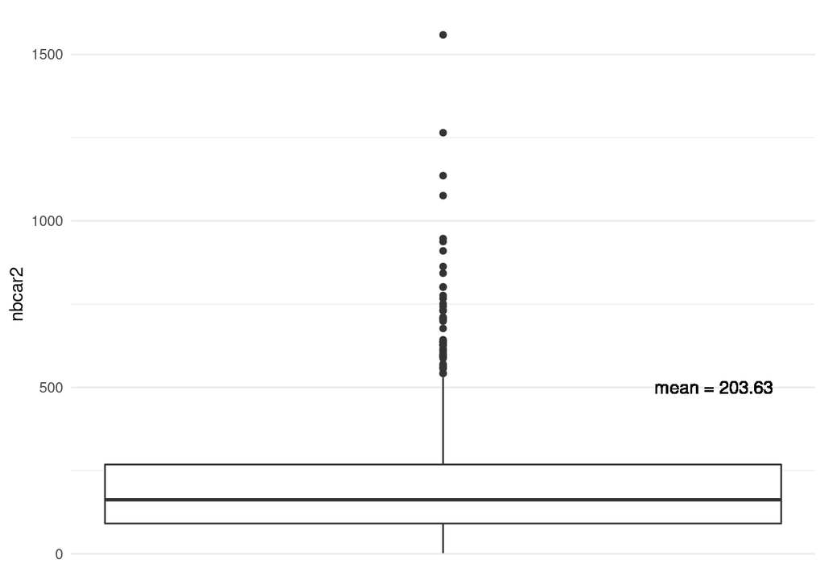

```r
moy<-round(mean(na.omit(data$nbcar2)), 2)

ggplot(data)+
  geom_boxplot(aes(nbcar2))+
  geom_text(aes(x=500, y=0.3,label=paste("mean =",moy)))+
  coord_flip()+
  scale_y_continuous(NULL, breaks = NULL)+
  theme_minimal()
```

# Les traitements préliminaires

On reprend ce qu’on a fait au cours dernier, sans éliminer les termes trop fréquents :

```r
corpus_airbnb<-corpus(data, text_field = "comments")

tok<-tokens(corpus_airbnb, remove_punct = TRUE, remove_numbers = TRUE, remove_symbols = TRUE)%>%
  tokens_remove(stopwords("fr"))

dfm<-dfm(tok)
```

# Co-occurrences

On va maintenant constituer des bi-grammes basés sur de nombreuses co-occurrences entre les termes :

```r
# textstat_collocations(tok)
head(textstat_collocations(tok), 5)
```

```
##            collocation count count_nested length   lambda        z
## 1           bien situé   182            0      2 4.701063 33.12404
## 2            très bien   216            0      2 2.485000 26.58585
## 3        très agréable   125            0      2 2.802686 21.68284
## 4           bon séjour    58            0      2 3.875408 21.66970
## 5 conforme description    32            0      2 6.510733 20.50046
```

```r
tail(textstat_collocations(tok),10)
```

```
##             collocation count count_nested length     lambda         z
## 1663 bien l'appartement     3            0      2 -0.6272317 -1.160471
## 1664          tout bien     3            0      2 -0.6745403 -1.248379
## 1665         métro très     4            0      2 -0.6230339 -1.298165
## 1666          plus très     2            0      2 -0.8653495 -1.349729
## 1667          tout très     7            0      2 -0.5872824 -1.576529
## 1668        séjour bien     3            0      2 -0.8707482 -1.613623
## 1669      appartement a     2            0      2 -1.0858991 -1.705262
## 1670         situé bien     2            0      2 -1.1096153 -1.741776
## 1671          bien très     2            0      2 -2.5827275 -4.069195
## 1672          très très    10            0      2 -1.9358956 -6.212276
```

```r
colloc<-textstat_collocations(tok, min_count = 10, tolower = TRUE)
head(colloc,10)
```

```
##             collocation count count_nested length   lambda        z
## 1            bien situé   182            0      2 4.701063 33.12404
## 2             très bien   216            0      2 2.485000 26.58585
## 3         très agréable   125            0      2 2.802686 21.68284
## 4            bon séjour    58            0      2 3.875408 21.66970
## 5  conforme description    32            0      2 6.510733 20.50046
## 6              très bon    89            0      2 3.459511 18.85531
## 7          qualité prix    25            0      2 7.464569 18.53883
## 8       rapport qualité    25            0      2 7.716042 18.02307
## 9   recommande vivement    33            0      2 6.730170 17.50930
## 10          bon accueil    28            0      2 4.177035 17.30312
```

```r
tail(colloc,10)
```

```
##            collocation count count_nested length      lambda          z
## 115         calme bien    15            0      2  0.89014310  3.3396342
## 116         calme très    20            0      2  0.49069736  2.1019480
## 117        propre très    16            0      2  0.48648776  1.8732529
## 118      agréable très    17            0      2  0.30607168  1.2218470
## 119 l'appartement bien    11            0      2  0.37072723  1.2183091
## 120   appartement bien    13            0      2  0.17730331  0.6323473
## 121             a bien    11            0      2  0.13519656  0.4461510
## 122        séjour très    17            0      2  0.10777256  0.4330590
## 123         situé très    15            0      2  0.08520971  0.3227570
## 124          très très    10            0      2 -1.93589563 -6.2122760
```

```r
#colloc

tok_cooc<-tokens_compound(tok, pattern = colloc[colloc$z>6])

tok["text100"]
```

```
## Tokens consisting of 1 document and 12 docvars.
## text100 :
##  [1] "Très"         "intéressante" "très"         "sympa"        "toujours"
##  [6] "l'écoute"     "n'hésitez"    "poser"        "questions"    "ville"
## [11] "avoir"        "plus"
## [ ... and 3 more ]
```

```r
tok_cooc["text100"]
```

```
## Tokens consisting of 1 document and 12 docvars.
## text100 :
##  [1] "Très"           "intéressante"   "très_sympa"     "toujours"
##  [5] "l'écoute"       "n'hésitez"      "poser"          "questions"
##  [9] "ville"          "avoir"          "plus"           "d'informations"
## [ ... and 2 more ]
```

Analyse de fréquence et représentation graphique :

```r
dfm_cooc<-dfm(tok_cooc)

dfm_cooc2<-dfm_trim(dfm_cooc, max_termfreq = 200)

head(textstat_frequency(dfm_cooc2),20)
```

```
##          feature frequency rank docfreq group
## 1           tout       197    1     165   all
## 2          calme       162    2     159   all
## 3           bien       142    3     120   all
## 4          paris       139    4     131   all
## 5         séjour       132    5     126   all
## 6     recommande       127    6     127   all
## 7       quartier       117    7     110   all
## 8          merci       116    8     115   all
## 9       logement       115    9     104   all
## 10      agréable       112   10     108   all
## 11          plus       104   11      89   all
## 12         super       104   11      93   all
## 13         métro       104   11     102   all
## 14       parfait        92   14      91   all
## 15        propre        79   15      76   all
## 16       chambre        75   16      67   all
## 17 très_agréable        73   17      73   all
## 18          hôte        70   18      70   all
## 19    bien_situé        67   19      67   all
## 20         petit        65   20      63   all
```

[figure not shown]

```r
textplot_wordcloud(dfm_cooc2, max_words = 200, color = brewer.pal(6, "Set2"))
```

```r
tok_cooc<-tokens_replace(tok_cooc, "très_bien_situé", "bien_situé")
```

## Représentation en réseau des termes co-occurents

```r
fcm_cooc<-fcm(dfm_cooc2)
fcm_cooc
```

```
## Feature co-occurrence matrix of: 3,871 by 3,871 features.
##             features
## features     j'ai passé semaines studio chaleureux allures chalet montagne
##   j'ai          3     1        1      3          3       0      0        0
##   passé         0     0        0      4          2       0      0        0
##   semaines      0     0        0      2          1       1      1        1
##   studio        0     0        0     12          2       2      2        2
##   chaleureux    0     0        0      0          0       1      1        1
##   allures       0     0        0      0          0       0      1        1
##   chalet        0     0        0      0          0       0      0        1
##   montagne      0     0        0      0          0       0      0        0
##   véronique     0     0        0      0          0       0      0        0
##   hôte          0     0        0      0          0       0      0        0
##             features
## features     véronique hôte
##   j'ai               1    8
##   passé              0    3
##   semaines           1    1
##   studio             2    6
##   chaleureux         1    6
##   allures            1    1
##   chalet             1    1
##   montagne           1    1
##   véronique          1    1
##   hôte               0    0
## [ reached max_feat ... 3,861 more features, reached max_nfeat ... 3,861 more features ]
```

```r
topfeatures(fcm_cooc)
```

```
##   très_agréable            tout       très_bien      bien_situé           calme
##            1163            1000             962             886             850
## très_bien_situé            deux      très_calme     très_propre           merci
##             732             729             723             722             700
```

```r
dim(fcm_cooc)
```

```
## [1] 3871 3871
```

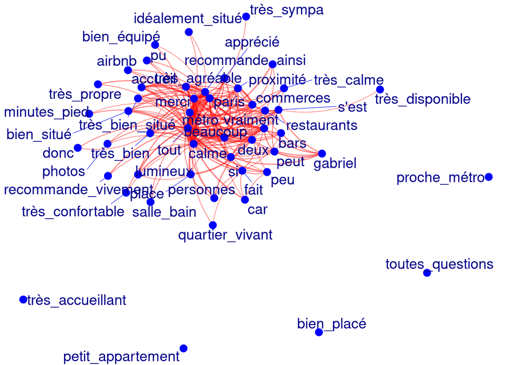

```r
feat<-names(topfeatures(fcm_cooc, 50))
fcm_cooc_select<-fcm_select(fcm_cooc, pattern = feat, selection = "keep")

textplot_network(fcm_cooc_select, min_freq = 0.8, edge_color = "red" , edge_alpha = 0.5, vertex_color = "blue",vertex_size = 3, vertex_labelcolor = "darkblue", omit_isolated = FALSE)
```

[figure not shown]

```r
tpfeat<-tibble(feat=names(topfeatures(fcm_cooc,50)),n=topfeatures(fcm_cooc,50))
tpfeat<-tpfeat%>%mutate(taille=n/200)

textplot_network(fcm_cooc_select, min_freq = 0.8, edge_color = "red" , edge_alpha = 0.5, vertex_color = "blue",vertex_size = tpfeat$taille, vertex_labelcolor = "darkblue", omit_isolated = FALSE)
```

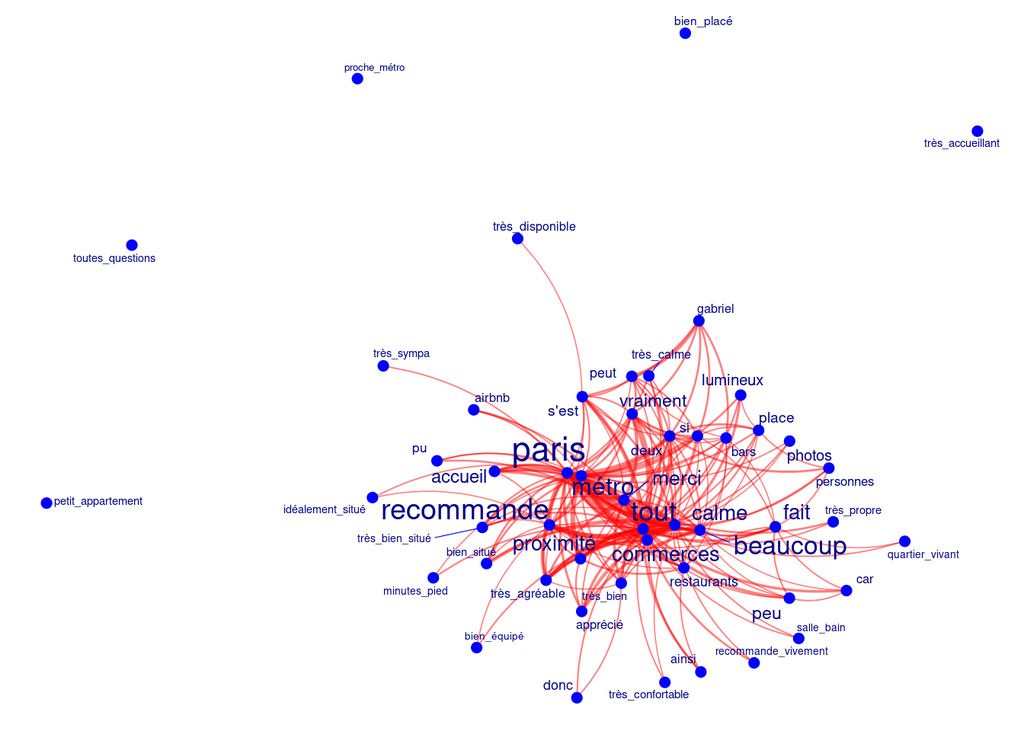

```r
textplot_network(fcm_cooc_select, min_freq = 0.8, edge_color = "red" , edge_alpha = 0.5, vertex_color = "blue", vertex_labelsize =  tpfeat$taille, vertex_labelcolor = "darkblue", omit_isolated = FALSE)
```

# Annotations

Pour cette partie, on repart du jeu de données brut.

## Détecter les langues

Dans le cas d’un corpus composé de plusieurs langues (par exemple, un corpus extrait de twitter), il peut être intéressant de filtrer le corpus à partir de la langue. On utilise un algorithme, qui peut être long à exécuter selon la taille du corpus, et qui est plutôt performant : cld3. Il repose sur un réseau de neurones développé par [Google](https://github.com/ropensci/cld3/blob/master/README.md)

```r
library(cld3)

data$langue<-detect_language(data$comments)
data$langue
```

```
##    [1] "fr" "fr" "fr" "fr" "fr" "fr" "fr" "fr" "fr" "fr" "fr" "fr" "fr" "fr"
##   [15] "fr" "fr" "fr" "fr" "fr" "fr" "fr" "fr" "fr" "fr" "fr" "fr" "fr" "fr"
##   [29] "fr" "fr" "fr" "fr" "fr" "fr" "fr" "fr" "fr" "fr" "fr" "fr" "fr" "fr"
##   [43] "fr" "fr" "fr" "fr" "fr" NA   "fr" "fr" "fr" "fr" "fr" "fr" "fr" "fr"
##   [57] "fr" "fr" "fr" "fr" "fr" "fr" "fr" "fr" "fr" "fr" "fr" "fr" "fr" "fr"
##   [71] "fr" "fr" "fr" "fr" "fr" "fr" "fr" "fr" "fr" "fr" "fr" "fr" "fr" "fr"
##   [85] "fr" "fr" "fr" "fr" "fr" "fr" "fr" "fr" "fr" "fr" "fr" "fr" "fr" "fr"
##   [99] "fr" "fr" "fr" "fr" "fr" "fr" "fr" "fr" "fr" "fr" "fr" "fr" "fr" "fr"
##  [113] "fr" "fr" "fr" "fr" "fr" "fr" "fr" "fr" "fr" "fr" "fr" "fr" "fr" "fr"
##  [127] "ca" "fr" "fr" "fr" "fr" "fr" "fr" "fr" "fr" "fr" "fr" "fr" "fr" "fr"
##  [141] "fr" "fr" "fr" "fr" "fr" "fr" "fr" "fr" "fr" "ht" "fr" "fr" "fr" "fr"
##  [155] "fr" "fr" "fr" "fr" "fr" "en" "fr" "fr" "fr" "fr" "fr" "fr" "fr" "fr"
##  [169] "fr" "fr" "fr" "fr" "fr" "ca" "fr" "fr" "fr" "fr" "fr" "fr" "fr" "fr"
##  [183] "fr" "fr" "fr" "fr" "fr" "fr" "fr" "fr" "fr" "fr" "fr" "fr" "fr" "fr"
##  [197] "fr" "fr" "fr" "fr" "fr" "fr" "fr" "fr" "fr" "fr" "fr" "fr" "fr" NA
```

[output cut: 57 more lines]

## POS

```r
library(cleanNLP)

cnlp_init_udpipe(model_name = "french")

annotate<-cnlp_annotate(data$comments, verbose = 100)
```

```
## Processed document 100 of 1000
## Processed document 200 of 1000
## Processed document 300 of 1000
## Processed document 400 of 1000
## Processed document 500 of 1000
## Processed document 600 of 1000
## Processed document 700 of 1000
## Processed document 800 of 1000
## Processed document 900 of 1000
## Processed document 1000 of 1000
```

```r
ann_token<-annotate$token
# write_csv2(ann_token, "annotation_Airbnb.csv")
# write_rds(ann_token,"annotation_Airbnb.rds")

ann_token%>%filter(upos=="ADJ"|upos=="NOUN"|upos=="VERB")
```

```
## # A tibble: 13,557 × 11
##    doc_id   sid tid   token        token_with_ws lemma upos  xpos  feats tid_source
##     <int> <int> <chr> <chr>        <chr>         <chr> <chr> <chr> <chr> <chr>
##  1      1     1 3     passé        "passé "      pass… VERB  <NA>  Gend… 0
##  2      1     1 5     semaines     "semaines "   sema… NOUN  <NA>  Gend… 3
##  3      1     1 8     studio       "studio "     stud… NOUN  <NA>  Gend… 3
##  4      1     1 9     chaleureux   "chaleureux"  chal… ADJ   <NA>  Gend… 8
##  5      1     1 13    allures      "allures "    allu… NOUN  <NA>  Gend… 3
##  6      1     1 15    chalet       "chalet "     chal… NOUN  <NA>  Gend… 13
##  7      1     1 17    montagne     "montagne"    mont… NOUN  <NA>  Gend… 15
##  8      1     2 4     hôte         "hôte "       hôte  NOUN  <NA>  Gend… 0
##  9      1     2 5     accueillante "accueillant… accu… ADJ   <NA>  Gend… 4
## 10      1     2 7     attentionnée "attentionné… atte… ADJ   <NA>  Gend… 5
## # … with 13,547 more rows, and 1 more variable: relation <chr>
```

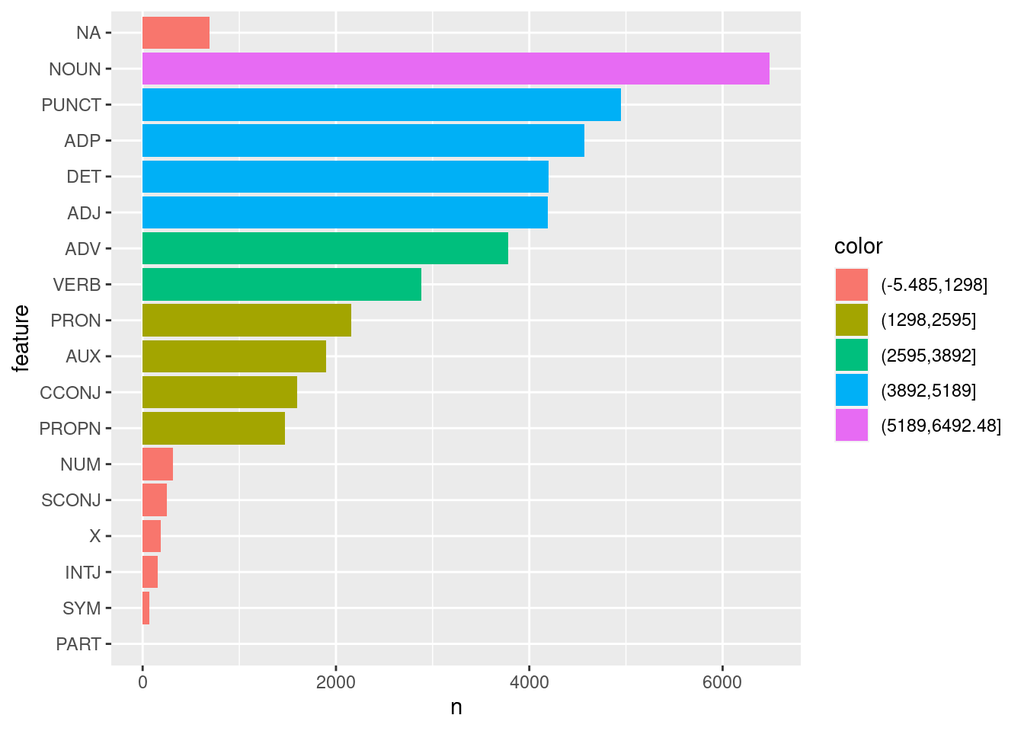

```r
g<-ann_token%>%group_by(upos)%>%
  summarise(n=n())%>%
  arrange(desc(n))%>%
  mutate(feature = factor(upos, levels = rev(unique(upos))))%>%
  mutate(color = cut(n, breaks = 5,dig.lab = -1))

ggplot(g)+
  geom_col(aes(feature,n, fill=color))+
  coord_flip()
```

Maintenant, on va s’intéresser à des catégories grammaticales spécifique :

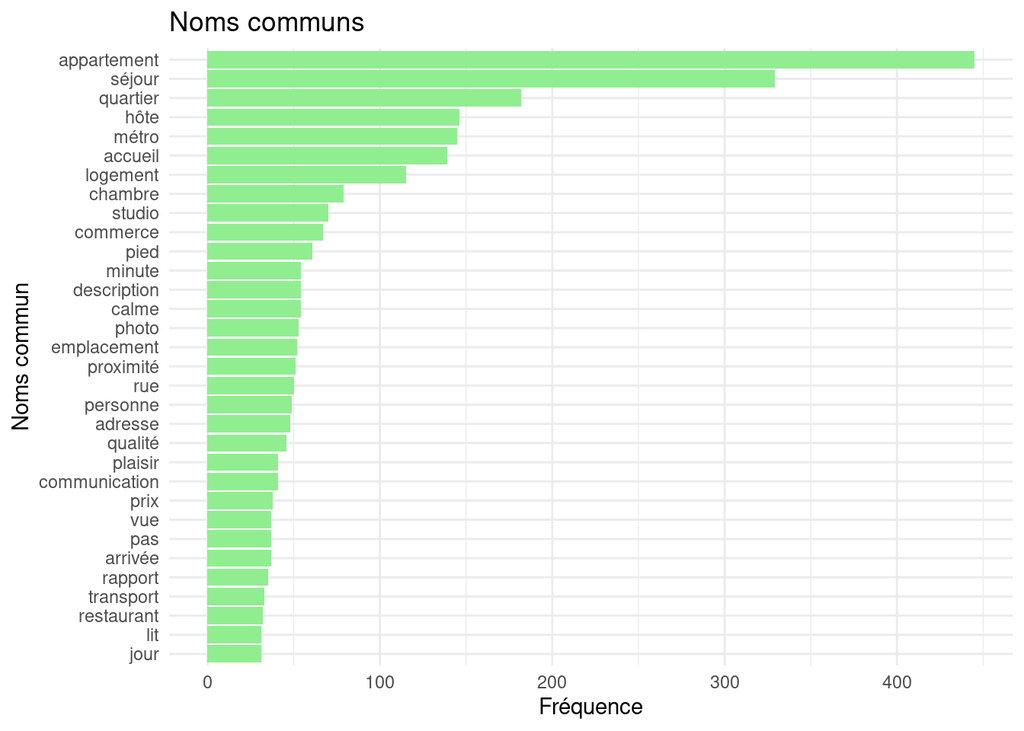

```r
Vocab1<-subset(ann_token, upos=="NOUN")
Table <- with(Vocab1, table(lemma))
ling<-as.data.frame(Table) %>% filter(Freq>30)
ggplot(ling,aes(x=reorder(lemma,Freq),y=Freq))+
  geom_bar(stat="identity",fill="lightgreen")+
  coord_flip()+
  theme_minimal()+
  labs(title = "Noms communs",x="Noms commun",y="Fréquence")
```

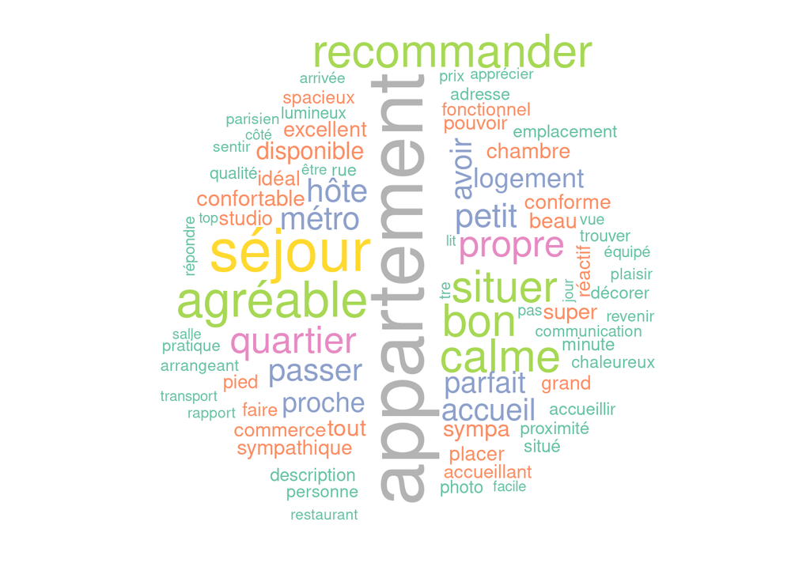

```r
Vocab2<-subset(ann_token, upos=="NOUN" | upos=="VERB" | upos=="ADJ")
Table2 <- with(Vocab2, table(lemma))
ling<-as.data.frame(Table2) %>% filter(Freq>30)

library(wordcloud)
wordcloud(words = ling$lemma, freq = ling$Freq, colors = brewer.pal(8, "Set2"),max.words=200, random.order = FALSE )
```